# V17 Analysis: Generalized Horizon + Trajectory Probing + Curriculum SIGReg

Published

April 18, 2026

## Overview

V17 introduces three changes to the V2 (V11) architecture:

1. **Fixed-window target + LogUniform horizon** Old: `target = ema_encoder(x_{t+1:t+k})`, length varies with `k`. New: `target = ema_encoder(x_{t+k:t+k+w})`, fixed `w=10`, offset `k ~ LogU[1, 150]`. *Why:* the target’s quality is constant across `k`; prediction difficulty alone scales with horizon. Equal-weight training across orders of magnitude of `k`.
2. **Trajectory probing** The predictor `gamma(k) = predictor(h_past, k)` is a latent dynamics model. Use it at inference: probe on `[h, gamma(5), gamma(10), gamma(20), gamma(50), gamma(100)]` (1536-dim) instead of `h_past` alone.
3. **Curriculum EMA -> SIGReg** Epochs 0-100: EMA only (proven V2 basin). Epochs 100-150: EMA + SIGReg `lambda` ramps `0 -> 0.05`. Epochs 150-200: No target network; target = `stop_grad(encoder(x_{future}))` + SIGReg maintains isotropy.

All phases evaluated with **F1 at k=30** (“fails within 30 cycles?”) alongside RMSE for direct comparison with anomaly detection literature.

## Setup

```python
import sys, json
from pathlib import Path
import numpy as np
import pandas as pd
import matplotlib.pyplot as plt
import matplotlib
matplotlib.rcParams.update({'font.size': 11, 'figure.dpi': 150})

V17_DIR = Path('/home/sagemaker-user/IndustrialJEPA/mechanical-jepa/experiments/v17')
PLOT_DIR = Path('/home/sagemaker-user/IndustrialJEPA/mechanical-jepa/analysis/plots/v17')
PLOT_DIR.mkdir(parents=True, exist_ok=True)

def safe_load(name):
    p = V17_DIR / name
    if not p.exists():
        return None
    with open(p) as f:
        return json.load(f)

r1 = safe_load('phase1_results.json')
r2 = safe_load('phase2_trajectory_probe_results.json')
r3 = safe_load('phase3_curriculum_results.json')
r4 = safe_load('phase4_tte_results.json')
r5 = safe_load('phase5_smap_results.json')
```

## Phase 1: V17 Baseline (LogUniform `k`, fixed-window target)

```python
if r1 is not None:
    print(f"Seeds: {r1.get('seeds')}")
    print(f"w={r1.get('w')}, K_max={r1.get('K_max')}, k_eval_f1={r1.get('k_eval_f1')}")
    print(f"Probe val RMSE per seed : {r1.get('probe_val_rmse_per_seed')}")
    print(f"Probe val RMSE mean     : "
          f"{r1.get('probe_val_rmse_mean'):.2f} +/- {r1.get('probe_val_rmse_std'):.2f}")
    print(f"Test  RMSE   per seed   : {r1.get('test_rmse_per_seed')}")
    print(f"Test  RMSE   mean       : "
          f"{r1.get('test_rmse_mean'):.2f} +/- {r1.get('test_rmse_std'):.2f}")
    print(f"Test  F1@k=30 mean      : {r1.get('f1_at_k30_mean'):.3f}")
    print(f"Test  AUC-PR  mean      : {r1.get('auc_pr_at_k30_mean'):.3f}")
    print(f"V2 baseline (reference) : 17.81")
else:
    print("Phase 1 results not available.")
```

```
Phase 1 results not available.
```

### LogUniform k distribution

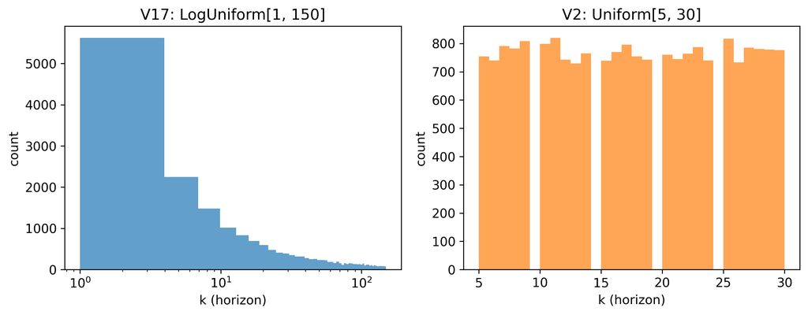

```python
import math
rng = np.random.RandomState(0)
K_max = 150
n = 20000
u = rng.uniform(0, math.log(K_max), size=n)
k_log = np.exp(u).astype(int).clip(1, K_max)
k_uni = rng.randint(5, 31, size=n)

fig, axes = plt.subplots(1, 2, figsize=(10, 4))
axes[0].hist(k_log, bins=50, color='tab:blue', alpha=0.7)
axes[0].set_xlabel('k (horizon)'); axes[0].set_ylabel('count')
axes[0].set_title(f'V17: LogUniform[1, {K_max}]')
axes[0].set_xscale('log')

axes[1].hist(k_uni, bins=30, color='tab:orange', alpha=0.7)
axes[1].set_xlabel('k (horizon)'); axes[1].set_ylabel('count')
axes[1].set_title('V2: Uniform[5, 30]')
fig.tight_layout(); plt.savefig(PLOT_DIR / 'k_distribution.png'); plt.show()
```

### Probe RMSE trajectory during pretraining

```python
if r1 is not None and 'histories' in r1:
    fig, axes = plt.subplots(1, 2, figsize=(12, 4))
    for i, h in enumerate(r1['histories']):
        seed = r1['seeds'][i] if i < len(r1['seeds']) else i
        eps = h.get('probe_epochs', [])
        v = h.get('probe_rmse', [])
        t = h.get('test_rmse', [])
        f1 = h.get('test_f1', [])
        axes[0].plot(eps, v, label=f'seed {seed} val', alpha=0.7)
        axes[0].plot(eps, t, '--', label=f'seed {seed} test', alpha=0.7)
        axes[1].plot(eps, f1, label=f'seed {seed}')
    axes[0].axhline(17.81, color='red', ls=':', label='V2 ref (17.81)')
    axes[0].set_xlabel('epoch'); axes[0].set_ylabel('RMSE')
    axes[0].set_title('Frozen probe RMSE during V17 pretraining')
    axes[0].legend(fontsize=8)
    axes[1].set_xlabel('epoch'); axes[1].set_ylabel('F1 @ k=30')
    axes[1].set_title('Binary F1 (fail within 30 cycles)')
    axes[1].legend(fontsize=8); axes[1].set_ylim(0, 1)
    fig.tight_layout(); plt.savefig(PLOT_DIR / 'phase1_rmse_f1_trajectory.png')
    plt.show()
else:
    print("Phase 1 histories not available.")
```

```
Phase 1 histories not available.
```

## Phase 2: Trajectory Probing

```python
if r2 is not None:
    rows = []
    for v, s in r2.get('variants', {}).items():
        rows.append({
            'variant': v,
            'test_rmse': f"{s['test_rmse_mean']:.2f}+/-{s['test_rmse_std']:.2f}",
            'val_rmse': f"{s['val_rmse_mean']:.2f}",
            'F1@30': f"{s['f1_mean']:.3f}",
            'AUC-PR': f"{s['auc_pr_mean']:.3f}",
        })
    df = pd.DataFrame(rows)
    print(df.to_string(index=False))
    print(f"\nV2 reference: 17.81 RMSE (n=5)")
else:
    print("Phase 2 results not available.")
```

```
Phase 2 results not available.
```

### Per-k informativeness

```python
if r2 is not None:
    ks = [5, 10, 20, 50, 100]
    rmses = []
    f1s = []
    for k in ks:
        v = r2['variants'].get(f'g{k}')
        if v is None:
            rmses.append(np.nan); f1s.append(np.nan); continue
        rmses.append(v['test_rmse_mean'])
        f1s.append(v['f1_mean'])
    h_rmse = r2['variants'].get('h', {}).get('test_rmse_mean')
    tr_rmse = r2['variants'].get('traj', {}).get('test_rmse_mean')

    fig, axes = plt.subplots(1, 2, figsize=(10, 4))
    axes[0].plot(ks, rmses, 'o-', label='gamma(k) alone')
    if h_rmse is not None:
        axes[0].axhline(h_rmse, color='tab:green', ls='--', label='h only')
    if tr_rmse is not None:
        axes[0].axhline(tr_rmse, color='tab:red', ls='--', label='concat [h, gamma(K_set)]')
    axes[0].axhline(17.81, color='gray', ls=':', label='V2 ref')
    axes[0].set_xscale('log'); axes[0].set_xlabel('k')
    axes[0].set_ylabel('Test RMSE')
    axes[0].set_title('Test RMSE per trajectory feature')
    axes[0].legend(fontsize=8)

    axes[1].plot(ks, f1s, 'o-')
    axes[1].set_xscale('log'); axes[1].set_xlabel('k')
    axes[1].set_ylabel('F1 @ k=30'); axes[1].set_ylim(0, 1)
    axes[1].set_title('F1@30 per trajectory feature')
    fig.tight_layout(); plt.savefig(PLOT_DIR / 'phase2_per_k_informativeness.png')
    plt.show()
```

## Phase 3: Curriculum EMA -> SIGReg

Transition schedule: - Epochs 100-150: EMA + `lambda_sig` linear ramp 0 -> 0.05 - Epochs 150-200: no EMA; target = `stop_grad(encoder(future))`; `lambda_sig=0.05`

Two variants: - **enc** : `SIGReg(h_past)` - regularizes encoder output - **pred**: `SIGReg(gamma(k))` - regularizes predictor output (novel; this is where probes operate)

```python
if r3 is not None:
    rows = []
    for v, s in r3.get('by_variant', {}).items():
        rows.append({
            'variant': v,
            'val_rmse': f"{s['val_rmse_mean']:.2f}",
            'test_rmse': f"{s['test_rmse_mean']:.2f}+/-{s['test_rmse_std']:.2f}",
            'F1@30': f"{s['f1_mean']:.3f}",
            'AUC-PR': f"{s['auc_pr_mean']:.3f}",
            'PC1': f"{s['pc1_final_mean']:.3f}",
        })
    df = pd.DataFrame(rows)
    print(df.to_string(index=False))
    print(f"\nV2 reference: 17.81 RMSE")
    print(f"V17 Phase 1 ref: {r1.get('test_rmse_mean', 'N/A'):.2f} RMSE" if r1 else "")
else:
    print("Phase 3 results not available.")
```

```
Phase 3 results not available.
```

### Curriculum transition plots

```python
if r3 is not None and 'histories' in r3:
    fig, axes = plt.subplots(2, 2, figsize=(12, 8))
    for h in r3['histories']:
        variant = h.get('mode', ['?'])[0] if h.get('mode') else '?'
        label = f"seed ep100+"
        if h.get('epoch'):
            axes[0, 0].plot(h['epoch'], h['loss'], alpha=0.6)
            axes[0, 0].set_title('Total loss (curriculum)')
            axes[0, 1].plot(h['epoch'], h.get('lambda_sig', [0]*len(h['epoch'])),
                             alpha=0.6)
            axes[0, 1].set_title('lambda_sig schedule')
        if h.get('probe_epochs'):
            axes[1, 0].plot(h['probe_epochs'], h['val_rmse'], 'o-', alpha=0.6)
            axes[1, 0].set_title('Val RMSE')
            if h.get('pc1_var'):
                axes[1, 1].plot(h['probe_epochs'], h['pc1_var'], 'o-', alpha=0.6)
                axes[1, 1].set_title('PC1 explained variance (isotropy)')
    for ax in axes.flat:
        ax.set_xlabel('epoch')
        ax.axvline(150, color='k', ls=':', alpha=0.5, label='EMA->SG switch')
    axes[1, 0].axhline(17.81, color='red', ls=':', alpha=0.5)
    fig.tight_layout(); plt.savefig(PLOT_DIR / 'phase3_curriculum.png')
    plt.show()
```

## Phase 4: TTE via Trajectory Sweep

Ground truth: sensor `s14`, `mu +/- 3 sigma` thresholds from cycles 1-50. Event-boundary probe: `gamma(k) -> p(TTE <= k)`. Inference: sweep `k` in `[1, 150]`, `TTE_hat = min{k : p_k > 0.5}`.

```python
if r4 is not None:
    print(f"Sensor     : {r4.get('sensor')} (idx {r4.get('s14_idx')})")
    print(f"Baseline   : {r4.get('baseline_window')} cycles, n_sigma={r4.get('n_sigma')}")
    print(f"K_max      : {r4.get('k_max')}")
    print(f"Binary F1 (fail within {r4.get('k_eval_f1')} cycles): "
          f"{r4.get('bin_f1_mean'):.3f}")
    print(f"Binary AUC-PR                  : {r4.get('bin_auc_pr_mean'):.3f}")
    print(f"TTE RMSE                       : {r4.get('tte_rmse_mean'):.2f}")
    print(f"\nPer-seed details:")
    for r in r4.get('per_seed', []):
        print(f"  seed {r['seed']}: bin_F1={r['bin_f1']:.3f}, "
              f"TTE_RMSE={r['tte_rmse']:.2f}, "
              f"n_valid={r['tte_n_valid']}/{r['n_test']}")
else:
    print("Phase 4 results not available.")
```

```
Phase 4 results not available.
```